# Tutorium_25_06_CaseStudy-Loan Data

dzt

6/24/2021

The goal is to find out which variables or predictors can be used to make a model that will predict “interest_rate”

interest_rate:Interest rate on the loan, in an annual percentage.

Resource from : https://openintro-ims.netlify.app/model-mlr.html#model-mlr

Dataset from : http://openintrostat.github.io/openintro/reference/loans_full_schema.html

# EDA

dataset from package “openintro”

```r
library(tidyverse)
library(skimr)
library(openintro)
```

## Overview

check first 6 lines of the dataset

```r
head(loans_full_schema)
```

```
## # A tibble: 6 x 55
##   emp_title         emp_length state homeownership annual_income verified_income
##   <chr>                  <dbl> <fct> <fct>                 <dbl> <fct>
## 1 "global config e…          3 NJ    MORTGAGE              90000 Verified
## 2 "warehouse offic…         10 HI    RENT                  40000 Not Verified
## 3 "assembly"                 3 WI    RENT                  40000 Source Verified
## 4 "customer servic…          1 PA    RENT                  30000 Not Verified
## 5 "security superv…         10 CA    RENT                  35000 Verified
## 6 ""                        NA KY    OWN                   34000 Not Verified
## # … with 49 more variables: debt_to_income <dbl>, annual_income_joint <dbl>,
## #   verification_income_joint <fct>, debt_to_income_joint <dbl>,
## #   delinq_2y <int>, months_since_last_delinq <int>,
## #   earliest_credit_line <dbl>, inquiries_last_12m <int>,
## #   total_credit_lines <int>, open_credit_lines <int>,
## #   total_credit_limit <int>, total_credit_utilized <int>,
## #   num_collections_last_12m <int>, num_historical_failed_to_pay <int>,
## #   months_since_90d_late <int>, current_accounts_delinq <int>,
## #   total_collection_amount_ever <int>, current_installment_accounts <int>,
## #   accounts_opened_24m <int>, months_since_last_credit_inquiry <int>,
## #   num_satisfactory_accounts <int>, num_accounts_120d_past_due <int>,
## #   num_accounts_30d_past_due <int>, num_active_debit_accounts <int>,
## #   total_debit_limit <int>, num_total_cc_accounts <int>,
## #   num_open_cc_accounts <int>, num_cc_carrying_balance <int>,
## #   num_mort_accounts <int>, account_never_delinq_percent <dbl>,
## #   tax_liens <int>, public_record_bankrupt <int>, loan_purpose <fct>,
## #   application_type <fct>, loan_amount <int>, term <dbl>, interest_rate <dbl>,
## #   installment <dbl>, grade <fct>, sub_grade <fct>, issue_month <fct>,
## #   loan_status <fct>, initial_listing_status <fct>, disbursement_method <fct>,
## #   balance <dbl>, paid_total <dbl>, paid_principal <dbl>, paid_interest <dbl>,
## #   paid_late_fees <dbl>
```

```r
skim(loans_full_schema)
```

[output not shown]

Data summary

| Name | loans_full_schema |
| --- | --- |
| Number of rows | 10000 |
| Number of columns | 55 |
| _______________________ |  |
| Column type frequency: |  |
| character | 1 |
| factor | 12 |
| numeric | 42 |
| ________________________ |  |
| Group variables | None |

**Variable type: character**

| skim_variable | n_missing | complete_rate | min | max | empty | n_unique | whitespace |
| --- | --- | --- | --- | --- | --- | --- | --- |
| emp_title | 0 | 1 | 0 | 40 | 833 | 4742 | 0 |

**Variable type: factor**

| skim_variable | n_missing | complete_rate | ordered | n_unique | top_counts |
| --- | --- | --- | --- | --- | --- |
| state | 0 | 1 | FALSE | 50 | CA: 1330, TX: 806, NY: 793, FL: 732 |
| homeownership | 0 | 1 | FALSE | 3 | MOR: 4789, REN: 3858, OWN: 1353, emp: 0 |
| verified_income | 0 | 1 | FALSE | 3 | Sou: 4116, Not: 3594, Ver: 2290, emp: 0 |
| verification_income_joint | 0 | 1 | FALSE | 4 | emp: 8545, Not: 611, Sou: 499, Ver: 345 |
| loan_purpose | 0 | 1 | FALSE | 12 | deb: 5144, cre: 2249, oth: 914, hom: 680 |
| application_type | 0 | 1 | FALSE | 2 | ind: 8505, joi: 1495, emp: 0 |
| grade | 0 | 1 | FALSE | 7 | B: 3037, C: 2653, A: 2459, D: 1446 |
| sub_grade | 0 | 1 | FALSE | 32 | B1: 647, B2: 638, B5: 631, C1: 597 |
| issue_month | 0 | 1 | FALSE | 3 | Mar: 3617, Jan: 3395, Feb: 2988, emp: 0 |
| loan_status | 0 | 1 | FALSE | 6 | Cur: 9375, Ful: 447, In : 67, Lat: 66 |
| initial_listing_status | 0 | 1 | FALSE | 2 | who: 8206, fra: 1794, emp: 0 |
| disbursement_method | 0 | 1 | FALSE | 2 | Cas: 9284, Dir: 716, emp: 0 |

**Variable type: numeric**

| skim_variable | n_missing | complete_rate | mean | sd | p0 | p25 | p50 | p75 | p100 | hist |
| --- | --- | --- | --- | --- | --- | --- | --- | --- | --- | --- |
| emp_length | 817 | 0.92 | 5.93 | 3.70 | 0.00 | 2.00 | 6.00 | 10.00 | 10.00 | ▅▃▂▂▇ |
| annual_income | 0 | 1.00 | 79222.15 | 64734.29 | 0.00 | 45000.00 | 65000.00 | 95000.00 | 2300000.00 | ▇▁▁▁▁ |
| debt_to_income | 24 | 1.00 | 19.31 | 15.00 | 0.00 | 11.06 | 17.57 | 25.00 | 469.09 | ▇▁▁▁▁ |
| annual_income_joint | 8505 | 0.15 | 127914.57 | 70168.38 | 19200.00 | 86833.50 | 113000.00 | 151545.50 | 1100000.00 | ▇▁▁▁▁ |
| debt_to_income_joint | 8505 | 0.15 | 19.98 | 8.05 | 0.32 | 14.16 | 19.72 | 25.50 | 39.98 | ▂▆▇▅▂ |
| delinq_2y | 0 | 1.00 | 0.22 | 0.68 | 0.00 | 0.00 | 0.00 | 0.00 | 13.00 | ▇▁▁▁▁ |
| months_since_last_delinq | 5658 | 0.43 | 36.76 | 21.63 | 1.00 | 19.00 | 34.00 | 53.00 | 118.00 | ▇▇▅▂▁ |
| earliest_credit_line | 0 | 1.00 | 2001.29 | 7.80 | 1963.00 | 1997.00 | 2003.00 | 2006.00 | 2015.00 | ▁▁▂▇▇ |
| inquiries_last_12m | 0 | 1.00 | 1.96 | 2.38 | 0.00 | 0.00 | 1.00 | 3.00 | 29.00 | ▇▁▁▁▁ |
| total_credit_lines | 0 | 1.00 | 22.68 | 11.89 | 2.00 | 14.00 | 21.00 | 29.00 | 87.00 | ▇▇▂▁▁ |
| open_credit_lines | 0 | 1.00 | 11.40 | 5.87 | 0.00 | 7.00 | 10.00 | 14.00 | 51.00 | ▇▆▁▁▁ |
| total_credit_limit | 0 | 1.00 | 183606.23 | 187632.71 | 0.00 | 51593.75 | 114667.00 | 267550.00 | 3386034.00 | ▇▁▁▁▁ |
| total_credit_utilized | 0 | 1.00 | 51049.06 | 53636.73 | 0.00 | 19185.50 | 36927.00 | 65421.00 | 942456.00 | ▇▁▁▁▁ |
| num_collections_last_12m | 0 | 1.00 | 0.01 | 0.13 | 0.00 | 0.00 | 0.00 | 0.00 | 3.00 | ▇▁▁▁▁ |
| num_historical_failed_to_pay | 0 | 1.00 | 0.17 | 0.69 | 0.00 | 0.00 | 0.00 | 0.00 | 52.00 | ▇▁▁▁▁ |
| months_since_90d_late | 7715 | 0.23 | 46.11 | 21.75 | 2.00 | 29.00 | 47.00 | 63.00 | 128.00 | ▅▇▇▁▁ |
| current_accounts_delinq | 0 | 1.00 | 0.00 | 0.01 | 0.00 | 0.00 | 0.00 | 0.00 | 1.00 | ▇▁▁▁▁ |
| total_collection_amount_ever | 0 | 1.00 | 184.33 | 2206.39 | 0.00 | 0.00 | 0.00 | 0.00 | 199308.00 | ▇▁▁▁▁ |
| current_installment_accounts | 0 | 1.00 | 2.66 | 2.94 | 0.00 | 1.00 | 2.00 | 3.00 | 35.00 | ▇▁▁▁▁ |
| accounts_opened_24m | 0 | 1.00 | 4.38 | 3.16 | 0.00 | 2.00 | 4.00 | 6.00 | 29.00 | ▇▃▁▁▁ |
| months_since_last_credit_inquiry | 1271 | 0.87 | 7.34 | 5.98 | 0.00 | 2.00 | 6.00 | 11.00 | 24.00 | ▇▆▃▂▁ |
| num_satisfactory_accounts | 0 | 1.00 | 11.38 | 5.86 | 0.00 | 7.00 | 10.00 | 14.00 | 51.00 | ▇▆▁▁▁ |
| num_accounts_120d_past_due | 318 | 0.97 | 0.00 | 0.00 | 0.00 | 0.00 | 0.00 | 0.00 | 0.00 | ▁▁▇▁▁ |
| num_accounts_30d_past_due | 0 | 1.00 | 0.00 | 0.01 | 0.00 | 0.00 | 0.00 | 0.00 | 1.00 | ▇▁▁▁▁ |
| num_active_debit_accounts | 0 | 1.00 | 3.60 | 2.43 | 0.00 | 2.00 | 3.00 | 5.00 | 32.00 | ▇▁▁▁▁ |
| total_debit_limit | 0 | 1.00 | 27357.41 | 26570.16 | 0.00 | 10000.00 | 19500.00 | 36100.00 | 386700.00 | ▇▁▁▁▁ |
| num_total_cc_accounts | 0 | 1.00 | 13.03 | 7.87 | 2.00 | 7.00 | 11.00 | 17.00 | 66.00 | ▇▃▁▁▁ |
| num_open_cc_accounts | 0 | 1.00 | 8.10 | 4.91 | 0.00 | 5.00 | 7.00 | 10.00 | 46.00 | ▇▃▁▁▁ |
| num_cc_carrying_balance | 0 | 1.00 | 5.23 | 3.33 | 0.00 | 3.00 | 5.00 | 7.00 | 43.00 | ▇▁▁▁▁ |
| num_mort_accounts | 0 | 1.00 | 1.38 | 1.72 | 0.00 | 0.00 | 1.00 | 2.00 | 14.00 | ▇▂▁▁▁ |
| account_never_delinq_percent | 0 | 1.00 | 94.65 | 9.16 | 14.30 | 92.60 | 100.00 | 100.00 | 100.00 | ▁▁▁▁▇ |
| tax_liens | 0 | 1.00 | 0.04 | 0.59 | 0.00 | 0.00 | 0.00 | 0.00 | 52.00 | ▇▁▁▁▁ |
| public_record_bankrupt | 0 | 1.00 | 0.12 | 0.34 | 0.00 | 0.00 | 0.00 | 0.00 | 3.00 | ▇▁▁▁▁ |
| loan_amount | 0 | 1.00 | 16361.92 | 10301.96 | 1000.00 | 8000.00 | 14500.00 | 24000.00 | 40000.00 | ▆▇▅▃▂ |
| term | 0 | 1.00 | 43.27 | 11.03 | 36.00 | 36.00 | 36.00 | 60.00 | 60.00 | ▇▁▁▁▃ |
| interest_rate | 0 | 1.00 | 12.43 | 5.00 | 5.31 | 9.43 | 11.98 | 15.05 | 30.94 | ▇▆▃▁▁ |
| installment | 0 | 1.00 | 476.21 | 294.85 | 30.75 | 256.04 | 398.42 | 644.69 | 1566.59 | ▇▇▃▂▁ |
| balance | 0 | 1.00 | 14458.92 | 9964.56 | 0.00 | 6679.07 | 12379.49 | 20690.18 | 40000.00 | ▇▇▅▂▂ |
| paid_total | 0 | 1.00 | 2494.23 | 3958.23 | 0.00 | 928.70 | 1563.30 | 2616.00 | 41630.44 | ▇▁▁▁▁ |
| paid_principal | 0 | 1.00 | 1894.45 | 3884.41 | 0.00 | 587.10 | 984.99 | 1694.56 | 40000.00 | ▇▁▁▁▁ |
| paid_interest | 0 | 1.00 | 599.67 | 517.33 | 0.00 | 221.76 | 446.14 | 825.42 | 4216.44 | ▇▂▁▁▁ |
| paid_late_fees | 0 | 1.00 | 0.12 | 1.81 | 0.00 | 0.00 | 0.00 | 0.00 | 52.98 | ▇▁▁▁▁ |

## Dataset division in Train and Test

select only 1000 lines of data

```r
loans_full_schema <- loans_full_schema %>%
  slice(1:1000)
loans_full_schema
```

```
## # A tibble: 1,000 x 55
##    emp_title        emp_length state homeownership annual_income verified_income
##    <chr>                 <dbl> <fct> <fct>                 <dbl> <fct>
##  1 "global config …          3 NJ    MORTGAGE              90000 Verified
##  2 "warehouse offi…         10 HI    RENT                  40000 Not Verified
##  3 "assembly"                3 WI    RENT                  40000 Source Verified
##  4 "customer servi…          1 PA    RENT                  30000 Not Verified
##  5 "security super…         10 CA    RENT                  35000 Verified
##  6 ""                       NA KY    OWN                   34000 Not Verified
##  7 "hr "                    10 MI    MORTGAGE              35000 Source Verified
##  8 "police"                 10 AZ    MORTGAGE             110000 Source Verified
##  9 "parts"                  10 NV    MORTGAGE              65000 Source Verified
## 10 "4th person"              3 IL    RENT                  30000 Not Verified
## # … with 990 more rows, and 49 more variables: debt_to_income <dbl>,
## #   annual_income_joint <dbl>, verification_income_joint <fct>,
## #   debt_to_income_joint <dbl>, delinq_2y <int>,
## #   months_since_last_delinq <int>, earliest_credit_line <dbl>,
## #   inquiries_last_12m <int>, total_credit_lines <int>,
## #   open_credit_lines <int>, total_credit_limit <int>,
## #   total_credit_utilized <int>, num_collections_last_12m <int>,
## #   num_historical_failed_to_pay <int>, months_since_90d_late <int>,
## #   current_accounts_delinq <int>, total_collection_amount_ever <int>,
## #   current_installment_accounts <int>, accounts_opened_24m <int>,
## #   months_since_last_credit_inquiry <int>, num_satisfactory_accounts <int>,
## #   num_accounts_120d_past_due <int>, num_accounts_30d_past_due <int>,
## #   num_active_debit_accounts <int>, total_debit_limit <int>,
## #   num_total_cc_accounts <int>, num_open_cc_accounts <int>,
## #   num_cc_carrying_balance <int>, num_mort_accounts <int>,
## #   account_never_delinq_percent <dbl>, tax_liens <int>,
## #   public_record_bankrupt <int>, loan_purpose <fct>, application_type <fct>,
## #   loan_amount <int>, term <dbl>, interest_rate <dbl>, installment <dbl>,
## #   grade <fct>, sub_grade <fct>, issue_month <fct>, loan_status <fct>,
## #   initial_listing_status <fct>, disbursement_method <fct>, balance <dbl>,
## #   paid_total <dbl>, paid_principal <dbl>, paid_interest <dbl>,
## #   paid_late_fees <dbl>
```

```r
train <-  slice_sample(loans_full_schema, prop=.75)
train
```

```
## # A tibble: 750 x 55
##    emp_title        emp_length state homeownership annual_income verified_income
##    <chr>                 <dbl> <fct> <fct>                 <dbl> <fct>
##  1 "senior engagem…         10 NJ    OWN                  230000 Source Verified
##  2 ""                       NA GA    MORTGAGE              17200 Not Verified
##  3 "security super…         10 CA    RENT                  35000 Verified
##  4 "carpenter"              10 NY    RENT                  56000 Not Verified
##  5 "call center ma…          9 IL    OWN                   39000 Source Verified
##  6 ""                       NA CA    OWN                   78000 Not Verified
##  7 "sales"                  10 FL    MORTGAGE             220000 Source Verified
##  8 "deputy assesso…          8 WV    MORTGAGE              50000 Verified
##  9 "cashier "                0 UT    RENT                  17000 Source Verified
## 10 "sales"                   4 TX    MORTGAGE             130000 Source Verified
## # … with 740 more rows, and 49 more variables: debt_to_income <dbl>,
## #   annual_income_joint <dbl>, verification_income_joint <fct>,
## #   debt_to_income_joint <dbl>, delinq_2y <int>,
## #   months_since_last_delinq <int>, earliest_credit_line <dbl>,
## #   inquiries_last_12m <int>, total_credit_lines <int>,
## #   open_credit_lines <int>, total_credit_limit <int>,
## #   total_credit_utilized <int>, num_collections_last_12m <int>,
## #   num_historical_failed_to_pay <int>, months_since_90d_late <int>,
## #   current_accounts_delinq <int>, total_collection_amount_ever <int>,
## #   current_installment_accounts <int>, accounts_opened_24m <int>,
## #   months_since_last_credit_inquiry <int>, num_satisfactory_accounts <int>,
## #   num_accounts_120d_past_due <int>, num_accounts_30d_past_due <int>,
## #   num_active_debit_accounts <int>, total_debit_limit <int>,
## #   num_total_cc_accounts <int>, num_open_cc_accounts <int>,
## #   num_cc_carrying_balance <int>, num_mort_accounts <int>,
## #   account_never_delinq_percent <dbl>, tax_liens <int>,
## #   public_record_bankrupt <int>, loan_purpose <fct>, application_type <fct>,
## #   loan_amount <int>, term <dbl>, interest_rate <dbl>, installment <dbl>,
## #   grade <fct>, sub_grade <fct>, issue_month <fct>, loan_status <fct>,
## #   initial_listing_status <fct>, disbursement_method <fct>, balance <dbl>,
## #   paid_total <dbl>, paid_principal <dbl>, paid_interest <dbl>,
## #   paid_late_fees <dbl>
```

```r
test <- anti_join(loans_full_schema, train, by="emp_title")
test
```

```
## # A tibble: 151 x 55
##    emp_title        emp_length state homeownership annual_income verified_income
##    <chr>                 <dbl> <fct> <fct>                 <dbl> <fct>
##  1 "warehouse offi…         10 HI    RENT                  40000 Not Verified
##  2 "hr "                    10 MI    MORTGAGE              35000 Source Verified
##  3 "respiratory th…          5 SC    MORTGAGE             122000 Source Verified
##  4 "onsite medical…          3 NV    RENT                  72000 Source Verified
##  5 "surveyor/cadd …          7 PA    MORTGAGE              55000 Source Verified
##  6 "associated "             1 NY    RENT                  55000 Source Verified
##  7 "armed protecti…          1 MD    OWN                   70000 Source Verified
##  8 "bank coordinat…          2 CA    RENT                  53592 Source Verified
##  9 "nurse assistan…          5 NC    MORTGAGE              70000 Not Verified
## 10 "physician assi…         10 MO    MORTGAGE             152000 Not Verified
## # … with 141 more rows, and 49 more variables: debt_to_income <dbl>,
## #   annual_income_joint <dbl>, verification_income_joint <fct>,
## #   debt_to_income_joint <dbl>, delinq_2y <int>,
## #   months_since_last_delinq <int>, earliest_credit_line <dbl>,
## #   inquiries_last_12m <int>, total_credit_lines <int>,
## #   open_credit_lines <int>, total_credit_limit <int>,
## #   total_credit_utilized <int>, num_collections_last_12m <int>,
## #   num_historical_failed_to_pay <int>, months_since_90d_late <int>,
## #   current_accounts_delinq <int>, total_collection_amount_ever <int>,
## #   current_installment_accounts <int>, accounts_opened_24m <int>,
## #   months_since_last_credit_inquiry <int>, num_satisfactory_accounts <int>,
## #   num_accounts_120d_past_due <int>, num_accounts_30d_past_due <int>,
## #   num_active_debit_accounts <int>, total_debit_limit <int>,
## #   num_total_cc_accounts <int>, num_open_cc_accounts <int>,
## #   num_cc_carrying_balance <int>, num_mort_accounts <int>,
## #   account_never_delinq_percent <dbl>, tax_liens <int>,
## #   public_record_bankrupt <int>, loan_purpose <fct>, application_type <fct>,
## #   loan_amount <int>, term <dbl>, interest_rate <dbl>, installment <dbl>,
## #   grade <fct>, sub_grade <fct>, issue_month <fct>, loan_status <fct>,
## #   initial_listing_status <fct>, disbursement_method <fct>, balance <dbl>,
## #   paid_total <dbl>, paid_principal <dbl>, paid_interest <dbl>,
## #   paid_late_fees <dbl>
```

## Train,test data adjustment (only for this dataset case as it is sooo huge)

update the train data contains following variables: verified_income, debt_to_income, issue_month, annual_income, total_credit_utilized and total_credit_limit

```r
train <- train %>%
  select(emp_title,interest_rate, verified_income, debt_to_income, issue_month,annual_income,total_credit_utilized, total_credit_limit)
train
```

```
## # A tibble: 750 x 8
##    emp_title            interest_rate verified_income debt_to_income issue_month
##    <chr>                        <dbl> <fct>                    <dbl> <fct>
##  1 "senior engagement …         10.9  Source Verified           9.19 Feb-2018
##  2 ""                           15.0  Not Verified             21.0  Feb-2018
##  3 "security superviso…         14.1  Verified                 58.0  Mar-2018
##  4 "carpenter"                  19.4  Not Verified             32.3  Mar-2018
##  5 "call center manage…         10.9  Source Verified          16.0  Mar-2018
##  6 ""                            6.08 Not Verified             20.3  Feb-2018
##  7 "sales"                      12.0  Source Verified           7.52 Feb-2018
##  8 "deputy assessor "            9.93 Verified                 12.2  Jan-2018
##  9 "cashier "                   19.0  Source Verified           5.44 Jan-2018
## 10 "sales"                      12.6  Source Verified          13.5  Feb-2018
## # … with 740 more rows, and 3 more variables: annual_income <dbl>,
## #   total_credit_utilized <int>, total_credit_limit <int>
```

```r
test <- test %>%
  select(emp_title,interest_rate, verified_income, debt_to_income, issue_month,annual_income,total_credit_utilized, total_credit_limit)
test
```

```
## # A tibble: 151 x 8
##    emp_title            interest_rate verified_income debt_to_income issue_month
##    <chr>                        <dbl> <fct>                    <dbl> <fct>
##  1 "warehouse office c…         12.6  Not Verified              5.04 Feb-2018
##  2 "hr "                        13.6  Source Verified          23.7  Jan-2018
##  3 "respiratory therap…         13.6  Source Verified          12.1  Feb-2018
##  4 "onsite medical "            28.7  Source Verified          20.3  Jan-2018
##  5 "surveyor/cadd tech"         12.6  Source Verified          14.4  Feb-2018
##  6 "associated "                12.0  Source Verified          13.7  Mar-2018
##  7 "armed protection o…          6.08 Source Verified           0    Jan-2018
##  8 "bank coordinator"           12.6  Source Verified           7.1  Feb-2018
##  9 "nurse assistant"             6.07 Not Verified             21.4  Mar-2018
## 10 "physician assistan…         13.6  Not Verified             21.1  Jan-2018
## # … with 141 more rows, and 3 more variables: annual_income <dbl>,
## #   total_credit_utilized <int>, total_credit_limit <int>
```

## Drop Missing values which are not so much large amount compare to the whole sample (<10%)

```r
skim(train)
```

Data summary

| Name | train |
| --- | --- |
| Number of rows | 750 |
| Number of columns | 8 |
| _______________________ |  |
| Column type frequency: |  |
| character | 1 |
| factor | 2 |
| numeric | 5 |
| ________________________ |  |
| Group variables | None |

**Variable type: character**

| skim_variable | n_missing | complete_rate | min | max | empty | n_unique | whitespace |
| --- | --- | --- | --- | --- | --- | --- | --- |
| emp_title | 0 | 1 | 0 | 40 | 55 | 547 | 0 |

**Variable type: factor**

| skim_variable | n_missing | complete_rate | ordered | n_unique | top_counts |
| --- | --- | --- | --- | --- | --- |
| verified_income | 0 | 1 | FALSE | 3 | Sou: 318, Not: 278, Ver: 154, emp: 0 |
| issue_month | 0 | 1 | FALSE | 3 | Mar: 264, Jan: 256, Feb: 230, emp: 0 |

**Variable type: numeric**

| skim_variable | n_missing | complete_rate | mean | sd | p0 | p25 | p50 | p75 | p100 | hist |
| --- | --- | --- | --- | --- | --- | --- | --- | --- | --- | --- |
| interest_rate | 0 | 1 | 12.23 | 5.09 | 5.31 | 7.97 | 10.91 | 15.04 | 30.79 | ▇▇▃▁▁ |
| debt_to_income | 1 | 1 | 18.80 | 13.88 | 0.00 | 10.83 | 17.26 | 23.73 | 204.13 | ▇▁▁▁▁ |
| annual_income | 0 | 1 | 79361.59 | 60730.88 | 0.00 | 45000.00 | 68000.00 | 94750.00 | 1020000.00 | ▇▁▁▁▁ |
| total_credit_utilized | 0 | 1 | 48810.32 | 49037.00 | 0.00 | 18717.75 | 36416.00 | 62307.25 | 497876.00 | ▇▁▁▁▁ |
| total_credit_limit | 0 | 1 | 176062.37 | 168477.34 | 500.00 | 50792.75 | 105725.50 | 264794.25 | 1049446.00 | ▇▃▁▁▁ |

```r
train <-
  train %>%
  drop_na(debt_to_income )
```

## Reshaping the data (pivot_longer)

```r
pivot <-
select_if(train,is.numeric) %>%  # select only numbers
  pivot_longer(everything(), names_to = "variable")
  # everything() is a convenient shorthand to pivot all variables. pivot_longer(everything()) https://jhudatascience.org/tidyversecourse/wrangle-data.html
pivot
```

```
## # A tibble: 3,745 x 2
##    variable                  value
##    <chr>                     <dbl>
##  1 interest_rate             10.9
##  2 debt_to_income             9.19
##  3 annual_income         230000
##  4 total_credit_utilized  53298
##  5 total_credit_limit    441037
##  6 interest_rate             15.0
##  7 debt_to_income            21.0
##  8 annual_income          17200
##  9 total_credit_utilized   9535
## 10 total_credit_limit     87348
## # … with 3,735 more rows
```

## Check outliers in outcome (interest_rate) using boxplot

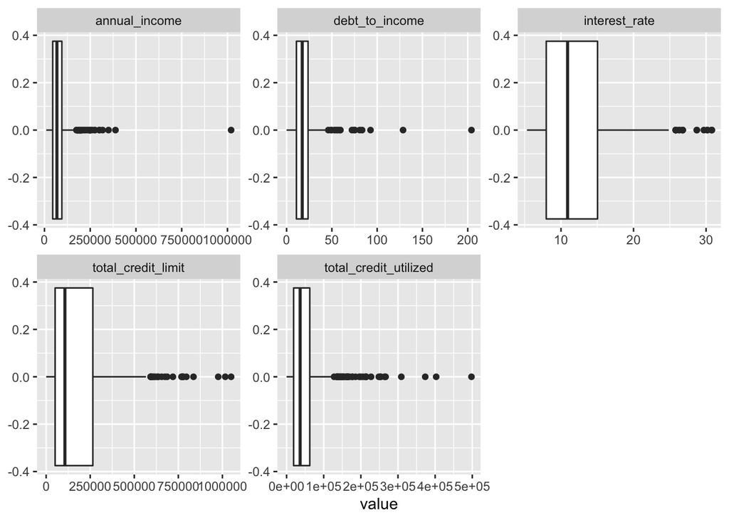

```r
pivot %>%
  ggplot(aes(x = value)) +
  geom_boxplot() +
  facet_wrap(~ variable, scales = "free")
```

## Check outliers in outcome(interest_rate) using Z value

z=(x-mean)/sd

```r
outliers<-
train %>%
mutate(interestrate_z = (interest_rate - mean(interest_rate, na.rm = TRUE)) /
sd(interest_rate, na.rm = TRUE)) %>%
mutate(is_extreme = if_else(abs(interestrate_z) > 3, TRUE, FALSE)) %>%
count(is_extreme)
```

```r
outliers
```

```
## # A tibble: 2 x 2
##   is_extreme     n
##   <lgl>      <int>
## 1 FALSE        741
## 2 TRUE           8
```

TRUE: outliers FALSE : not outliers

## Drop outliers in outcome (filter)

```r
train_outliers <- train%>%mutate(interestrate_z = (interest_rate - mean(interest_rate, na.rm = TRUE)) /
sd(interest_rate, na.rm = TRUE)) %>%
mutate(is_extreme = if_else(abs(interestrate_z) > 3, TRUE, FALSE))
train_outliers
```

```
## # A tibble: 749 x 10
##    emp_title            interest_rate verified_income debt_to_income issue_month
##    <chr>                        <dbl> <fct>                    <dbl> <fct>
##  1 "senior engagement …         10.9  Source Verified           9.19 Feb-2018
##  2 ""                           15.0  Not Verified             21.0  Feb-2018
##  3 "security superviso…         14.1  Verified                 58.0  Mar-2018
##  4 "carpenter"                  19.4  Not Verified             32.3  Mar-2018
##  5 "call center manage…         10.9  Source Verified          16.0  Mar-2018
##  6 ""                            6.08 Not Verified             20.3  Feb-2018
##  7 "sales"                      12.0  Source Verified           7.52 Feb-2018
##  8 "deputy assessor "            9.93 Verified                 12.2  Jan-2018
##  9 "cashier "                   19.0  Source Verified           5.44 Jan-2018
## 10 "sales"                      12.6  Source Verified          13.5  Feb-2018
## # … with 739 more rows, and 5 more variables: annual_income <dbl>,
## #   total_credit_utilized <int>, total_credit_limit <int>,
## #   interestrate_z <dbl>, is_extreme <lgl>
```

```r
train <-
  train_outliers %>%
  filter(is_extreme==FALSE)
train
```

```
## # A tibble: 741 x 10
##    emp_title            interest_rate verified_income debt_to_income issue_month
##    <chr>                        <dbl> <fct>                    <dbl> <fct>
##  1 "senior engagement …         10.9  Source Verified           9.19 Feb-2018
##  2 ""                           15.0  Not Verified             21.0  Feb-2018
##  3 "security superviso…         14.1  Verified                 58.0  Mar-2018
##  4 "carpenter"                  19.4  Not Verified             32.3  Mar-2018
##  5 "call center manage…         10.9  Source Verified          16.0  Mar-2018
##  6 ""                            6.08 Not Verified             20.3  Feb-2018
##  7 "sales"                      12.0  Source Verified           7.52 Feb-2018
##  8 "deputy assessor "            9.93 Verified                 12.2  Jan-2018
##  9 "cashier "                   19.0  Source Verified           5.44 Jan-2018
## 10 "sales"                      12.6  Source Verified          13.5  Feb-2018
## # … with 731 more rows, and 5 more variables: annual_income <dbl>,
## #   total_credit_utilized <int>, total_credit_limit <int>,
## #   interestrate_z <dbl>, is_extreme <lgl>
```

## Distribution of outcome

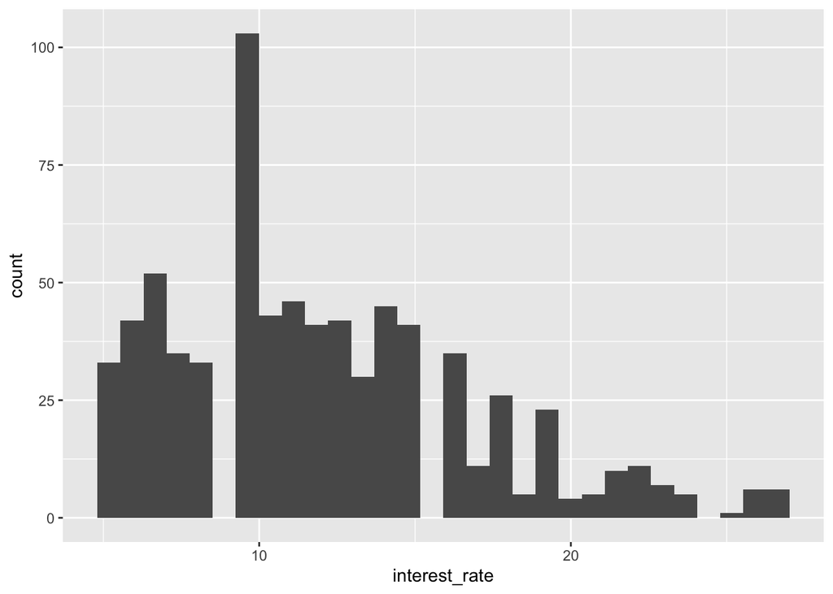

```r
train%>%
ggplot(aes(x=interest_rate)) + geom_histogram()
```

## Distribution of all predictors

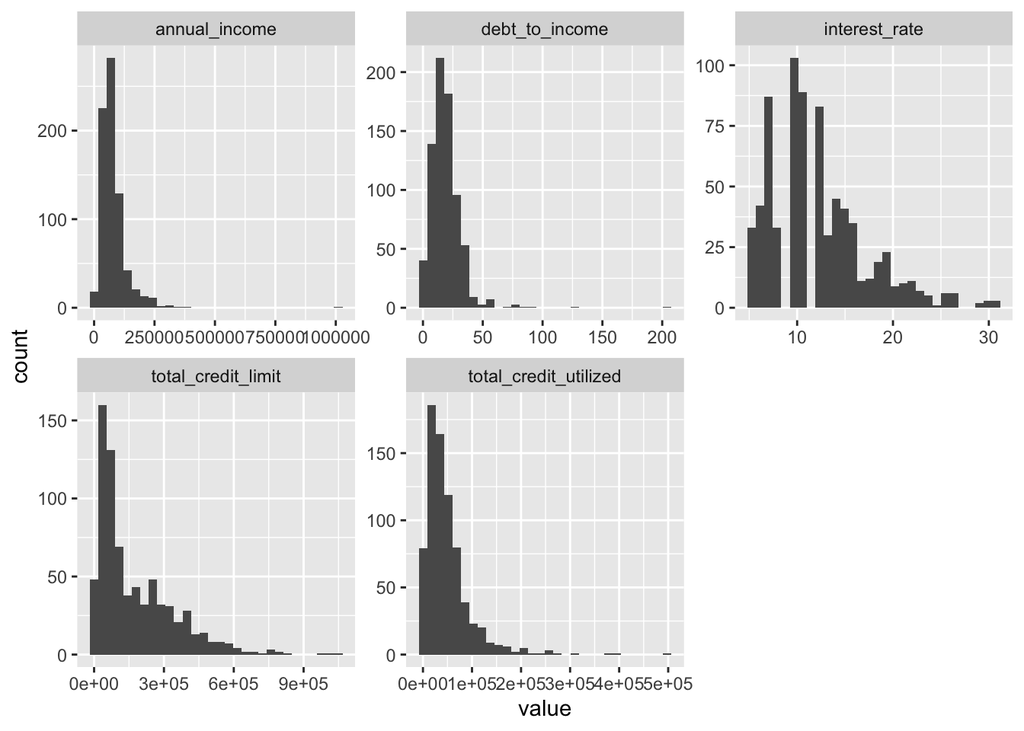

```r
  ggplot(pivot,aes(x = value)) +
  geom_histogram() +
  facet_wrap(~ variable, scales = "free")
```

## Transform (via logarithm)

```r
train<- train%>%
  mutate(annual_income_log10=log10(annual_income),total_credit_limit_log10=log10(total_credit_limit))
train
```

```
## # A tibble: 741 x 12
##    emp_title            interest_rate verified_income debt_to_income issue_month
##    <chr>                        <dbl> <fct>                    <dbl> <fct>
##  1 "senior engagement …         10.9  Source Verified           9.19 Feb-2018
##  2 ""                           15.0  Not Verified             21.0  Feb-2018
##  3 "security superviso…         14.1  Verified                 58.0  Mar-2018
##  4 "carpenter"                  19.4  Not Verified             32.3  Mar-2018
##  5 "call center manage…         10.9  Source Verified          16.0  Mar-2018
##  6 ""                            6.08 Not Verified             20.3  Feb-2018
##  7 "sales"                      12.0  Source Verified           7.52 Feb-2018
##  8 "deputy assessor "            9.93 Verified                 12.2  Jan-2018
##  9 "cashier "                   19.0  Source Verified           5.44 Jan-2018
## 10 "sales"                      12.6  Source Verified          13.5  Feb-2018
## # … with 731 more rows, and 7 more variables: annual_income <dbl>,
## #   total_credit_utilized <int>, total_credit_limit <int>,
## #   interestrate_z <dbl>, is_extreme <lgl>, annual_income_log10 <dbl>,
## #   total_credit_limit_log10 <dbl>
```

```r
train_new <- train%>% select(-interestrate_z,-emp_title)
train_new
```

```
## # A tibble: 741 x 10
##    interest_rate verified_income debt_to_income issue_month annual_income
##            <dbl> <fct>                    <dbl> <fct>               <dbl>
##  1         10.9  Source Verified           9.19 Feb-2018           230000
##  2         15.0  Not Verified             21.0  Feb-2018            17200
##  3         14.1  Verified                 58.0  Mar-2018            35000
##  4         19.4  Not Verified             32.3  Mar-2018            56000
##  5         10.9  Source Verified          16.0  Mar-2018            39000
##  6          6.08 Not Verified             20.3  Feb-2018            78000
##  7         12.0  Source Verified           7.52 Feb-2018           220000
##  8          9.93 Verified                 12.2  Jan-2018            50000
##  9         19.0  Source Verified           5.44 Jan-2018            17000
## 10         12.6  Source Verified          13.5  Feb-2018           130000
## # … with 731 more rows, and 5 more variables: total_credit_utilized <int>,
## #   total_credit_limit <int>, is_extreme <lgl>, annual_income_log10 <dbl>,
## #   total_credit_limit_log10 <dbl>
```

# Model

## The regsubsets() function (best sample)

(part of the leaps library) performs best subregsubsets() set selection by identifying the best model that contains a given number of predictors, where best is quantified using RSS From: ISLR Book 6.5

```r
library (leaps)
model <- regsubsets (interest_rate ~., train_new, really.big=T)
```

```
## Reordering variables and trying again:
```

```r
summary (model)
```

```
## Subset selection object
## Call: regsubsets.formula(interest_rate ~ ., train_new, really.big = T)
## 13 Variables  (and intercept)
##                                Forced in Forced out
## verified_incomeNot Verified        FALSE      FALSE
## verified_incomeSource Verified     FALSE      FALSE
## debt_to_income                     FALSE      FALSE
## issue_monthFeb-2018                FALSE      FALSE
## issue_monthJan-2018                FALSE      FALSE
## annual_income                      FALSE      FALSE
## total_credit_utilized              FALSE      FALSE
## total_credit_limit                 FALSE      FALSE
## annual_income_log10                FALSE      FALSE
## total_credit_limit_log10           FALSE      FALSE
## verified_incomeVerified            FALSE      FALSE
## issue_monthMar-2018                FALSE      FALSE
## is_extremeTRUE                     FALSE      FALSE
## 1 subsets of each size up to 9
## Selection Algorithm: exhaustive
##          verified_incomeNot Verified verified_incomeSource Verified
## 1  ( 1 ) " "                         " "
## 2  ( 1 ) " "                         " "
## 3  ( 1 ) "*"                         " "
## 4  ( 1 ) "*"                         " "
## 5  ( 1 ) " "                         "*"
## 6  ( 1 ) "*"                         "*"
## 7  ( 1 ) "*"                         "*"
## 8  ( 1 ) "*"                         "*"
## 9  ( 1 ) "*"                         "*"
##          verified_incomeVerified debt_to_income issue_monthFeb-2018
## 1  ( 1 ) "*"                     " "            " "
## 2  ( 1 ) "*"                     " "            " "
## 3  ( 1 ) "*"                     " "            " "
## 4  ( 1 ) "*"                     "*"            " "
## 5  ( 1 ) "*"                     "*"            " "
## 6  ( 1 ) " "                     "*"            "*"
## 7  ( 1 ) " "                     "*"            "*"
## 8  ( 1 ) " "                     "*"            "*"
## 9  ( 1 ) " "                     "*"            "*"
##          issue_monthJan-2018 issue_monthMar-2018 annual_income
```

[output cut: 14 more lines]

```
## 5  ( 1 ) "*"                   " "                " "
## 6  ( 1 ) "*"                   " "                " "
## 7  ( 1 ) "*"                   " "                " "
## 8  ( 1 ) "*"                   " "                " "
## 9  ( 1 ) "*"                   "*"                " "
##          annual_income_log10 total_credit_limit_log10
## 1  ( 1 ) " "                 " "
## 2  ( 1 ) " "                 "*"
## 3  ( 1 ) " "                 "*"
## 4  ( 1 ) " "                 "*"
## 5  ( 1 ) " "                 "*"
## 6  ( 1 ) " "                 "*"
## 7  ( 1 ) " "                 "*"
## 8  ( 1 ) " "                 "*"
## 9  ( 1 ) " "                 "*"
```

```r
reg.summary =summary (model)
names(reg.summary)
```

```
## [1] "which"  "rsq"    "rss"    "adjr2"  "cp"     "bic"    "outmat" "obj"
```

```r
reg.summary$adjr2
```

```
## [1] 0.08040274 0.10107319 0.12173253 0.13210233 0.13794824 0.14064141 0.14019723
## [8] 0.13909104 0.13793164
```

## Model1

```r
model1 <- lm(interest_rate ~ verified_income + debt_to_income + total_credit_utilized +total_credit_limit+ annual_income_log10 + total_credit_limit_log10  ,data = train_new )
```

```r
summary(model1)
```

```
##
## Call:
## lm(formula = interest_rate ~ verified_income + debt_to_income +
##     total_credit_utilized + total_credit_limit + annual_income_log10 +
##     total_credit_limit_log10, data = train_new)
##
## Residuals:
##      Min       1Q   Median       3Q      Max
## -12.9483  -3.2182  -0.5494   2.5136  15.9096
##
## Coefficients:
##                                  Estimate Std. Error t value Pr(>|t|)
## (Intercept)                     1.881e+01  4.334e+00   4.340 1.63e-05 ***
## verified_incomeSource Verified  1.570e+00  3.673e-01   4.274 2.17e-05 ***
## verified_incomeVerified         3.966e+00  4.584e-01   8.650  < 2e-16 ***
## debt_to_income                  3.913e-02  1.502e-02   2.606 0.009360 **
## total_credit_utilized           8.446e-06  4.385e-06   1.926 0.054454 .
## total_credit_limit              4.609e-07  1.963e-06   0.235 0.814447
## annual_income_log10             6.286e-01  8.655e-01   0.726 0.467855
## total_credit_limit_log10       -2.486e+00  7.139e-01  -3.482 0.000527 ***
## ---
## Signif. codes:  0 '***' 0.001 '**' 0.01 '*' 0.05 '.' 0.1 ' ' 1
##
## Residual standard error: 4.439 on 733 degrees of freedom
## Multiple R-squared:  0.1444, Adjusted R-squared:  0.1363
## F-statistic: 17.68 on 7 and 733 DF,  p-value: < 2.2e-16
```

## Model2

```r
model2 <- lm(interest_rate ~ verified_income + debt_to_income + total_credit_utilized +total_credit_limit+ annual_income_log10 + total_credit_limit_log10 + total_credit_utilized:verified_income ,data = train_new )
summary(model2)
```

```
##
## Call:
## lm(formula = interest_rate ~ verified_income + debt_to_income +
##     total_credit_utilized + total_credit_limit + annual_income_log10 +
##     total_credit_limit_log10 + total_credit_utilized:verified_income,
##     data = train_new)
##
## Residuals:
##      Min       1Q   Median       3Q      Max
## -12.8084  -3.2262  -0.6052   2.5321  15.8985
##
## Coefficients:
##                                                        Estimate Std. Error
## (Intercept)                                           1.884e+01  4.371e+00
## verified_incomeSource Verified                        2.247e+00  5.148e-01
## verified_incomeVerified                               4.076e+00  6.707e-01
## debt_to_income                                        3.712e-02  1.505e-02
## total_credit_utilized                                 1.717e-05  7.004e-06
## total_credit_limit                                    3.516e-07  1.964e-06
## annual_income_log10                                   5.418e-01  8.696e-01
## total_credit_limit_log10                             -2.474e+00  7.130e-01
## verified_incomeSource Verified:total_credit_utilized -1.452e-05  7.809e-06
## verified_incomeVerified:total_credit_utilized        -3.355e-06  9.829e-06
##                                                      t value Pr(>|t|)
## (Intercept)                                            4.310 1.86e-05 ***
## verified_incomeSource Verified                         4.366 1.45e-05 ***
## verified_incomeVerified                                6.078 1.96e-09 ***
## debt_to_income                                         2.467 0.013860 *
## total_credit_utilized                                  2.451 0.014472 *
## total_credit_limit                                     0.179 0.857993
## annual_income_log10                                    0.623 0.533389
## total_credit_limit_log10                              -3.469 0.000552 ***
## verified_incomeSource Verified:total_credit_utilized  -1.859 0.063432 .
## verified_incomeVerified:total_credit_utilized         -0.341 0.732926
## ---
## Signif. codes:  0 '***' 0.001 '**' 0.01 '*' 0.05 '.' 0.1 ' ' 1
##
## Residual standard error: 4.433 on 731 degrees of freedom
## Multiple R-squared:  0.1491, Adjusted R-squared:  0.1386
## F-statistic: 14.23 on 9 and 731 DF,  p-value: < 2.2e-16
```

# Prediction

```r
test<- test%>%
  mutate(annual_income_log10=log(annual_income),total_credit_limit_log10=log(total_credit_limit))

test
```

```
## # A tibble: 151 x 10
##    emp_title            interest_rate verified_income debt_to_income issue_month
##    <chr>                        <dbl> <fct>                    <dbl> <fct>
##  1 "warehouse office c…         12.6  Not Verified              5.04 Feb-2018
##  2 "hr "                        13.6  Source Verified          23.7  Jan-2018
##  3 "respiratory therap…         13.6  Source Verified          12.1  Feb-2018
##  4 "onsite medical "            28.7  Source Verified          20.3  Jan-2018
##  5 "surveyor/cadd tech"         12.6  Source Verified          14.4  Feb-2018
##  6 "associated "                12.0  Source Verified          13.7  Mar-2018
##  7 "armed protection o…          6.08 Source Verified           0    Jan-2018
##  8 "bank coordinator"           12.6  Source Verified           7.1  Feb-2018
##  9 "nurse assistant"             6.07 Not Verified             21.4  Mar-2018
## 10 "physician assistan…         13.6  Not Verified             21.1  Jan-2018
## # … with 141 more rows, and 5 more variables: annual_income <dbl>,
## #   total_credit_utilized <int>, total_credit_limit <int>,
## #   annual_income_log10 <dbl>, total_credit_limit_log10 <dbl>
```

```r
pred <- predict(model2, newdata = test)
head(pred)
```

```
##          1          2          3          4          5          6
## -0.5521319 -3.3463300 -2.7945424  0.8931765 -2.5217724  1.2627536
```

```r
test2 <- mutate(test, pred)
test2
```

```
## # A tibble: 151 x 11
##    emp_title            interest_rate verified_income debt_to_income issue_month
##    <chr>                        <dbl> <fct>                    <dbl> <fct>
##  1 "warehouse office c…         12.6  Not Verified              5.04 Feb-2018
##  2 "hr "                        13.6  Source Verified          23.7  Jan-2018
##  3 "respiratory therap…         13.6  Source Verified          12.1  Feb-2018
##  4 "onsite medical "            28.7  Source Verified          20.3  Jan-2018
##  5 "surveyor/cadd tech"         12.6  Source Verified          14.4  Feb-2018
##  6 "associated "                12.0  Source Verified          13.7  Mar-2018
##  7 "armed protection o…          6.08 Source Verified           0    Jan-2018
##  8 "bank coordinator"           12.6  Source Verified           7.1  Feb-2018
##  9 "nurse assistant"             6.07 Not Verified             21.4  Mar-2018
## 10 "physician assistan…         13.6  Not Verified             21.1  Jan-2018
## # … with 141 more rows, and 6 more variables: annual_income <dbl>,
## #   total_credit_utilized <int>, total_credit_limit <int>,
## #   annual_income_log10 <dbl>, total_credit_limit_log10 <dbl>, pred <dbl>
```

```r
handover<- select(test2, pred,emp_title)
handover
```

```
## # A tibble: 151 x 2
##      pred emp_title
##     <dbl> <chr>
##  1 -0.552 "warehouse office clerk"
##  2 -3.35  "hr "
##  3 -2.79  "respiratory therapist & sleep lab tech"
##  4  0.893 "onsite medical "
##  5 -2.52  "surveyor/cadd tech"
##  6  1.26  "associated "
##  7  1.60  "armed protection officer "
##  8  0.926 "bank coordinator"
##  9 -4.36  "nurse assistant"
## 10 -4.01  "physician assistant"
## # … with 141 more rows
```